# Unit3_Drill_DescriptiveStatsAndNormality

Choose 6 distributions from the list of random distributions available in NumPy, called “Distributions”

For each distribution:

1. Generate a random variable with 100 datapoints using the code distributionvar = np.random.distributionname([arguments], 100), replacing distributionvar with an appropriate variable name and distributionname with the name of the distribution you’ve chosen, and filling in the empty space in the parentheses with your chosen values for the appropriate parameters. If you feel uncertain about how to do this, go back to the “Other Distributions” assignment for examples of code to use as a starting point.
2. Graph the variable using a histogram.
3. Compute the mean and standard deviation and plot them as vertical lines on the histogram. (Hint: the “When Does It Break?” assignment you just completed can help you here.)
4. Evaluate whether the descriptive statistics provided useful information about the variable. Can you identify any common characteristics of the distributions that could be usefully described using the mean and/or standard deviation, versus the ones that could not?

Additionally:

1. Generate two normally-distributed variables, one with a mean of 5 and standard deviation of 0.5, and the other with a mean of 10 and standard deviation of 1.
2. Add them together to create a third variable.
3. Graph the third variable using a histogram.
4. Compute the mean and standard deviation and plot them as vertical lines on the histogram.
5. Evaluate the descriptive statistics against the data.

```python
import numpy as np
import pandas as pd
import matplotlib.pyplot as plt
%matplotlib inline

def plot_hist(distribution):
    #Plot a histogram.
    plt.hist(distribution)

    # Add a vertical line at the mean.
    plt.axvline(distribution.mean(), color='b', linestyle='solid', linewidth=2)

    # Add a vertical line at one standard deviation above the mean.
    plt.axvline(distribution.mean() + distribution.std(), color='b', linestyle='dashed', linewidth=2)

    # Add a vertical line at one standard deviation below the mean.
    plt.axvline(distribution.mean() - distribution.std(), color='b', linestyle='dashed', linewidth=2)

    # Print the histogram
    print('Mean: ', distribution.mean())
    print('Std: ', distribution.std())
    plt.show()
```

```
Mean:  0.42
Std:  0.49355850717012273
```

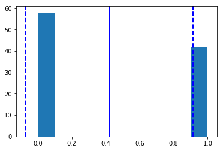

```python
#distributionvar = np.random.distributionname([arguments], 100),

n, p = 1, .5  # number of trials, probability of each trial
bernoulli = np.random.binomial(n, p, 100)

#Plot a histogram.
plot_hist(bernoulli)
```

```
Mean:  0.95
Std:  0.9836157786453001
```

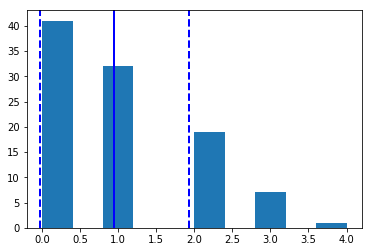

```python
poisson = np.random.poisson(1, 100)

#Plot a histogram.
plot_hist(poisson)
```

```
Mean:  5.175870713702023
Std:  2.36410548467532
```

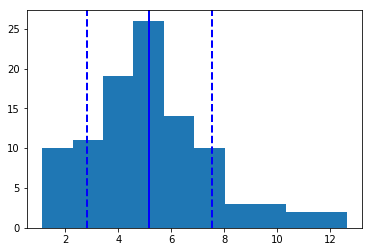

```python
gamma = np.random.gamma(5,1, 100)

#Plot a histogram.
plot_hist(gamma)
```

```
Mean:  9.73
Std:  0.48692915295759404
```

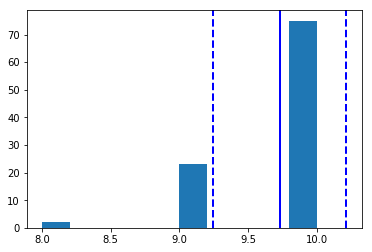

```python
ngood, nbad, nsamp = 100, 2, 10
# number of good, number of bad, and number of samples
hypergeometric = np.random.hypergeometric(ngood, nbad, nsamp, 100)

#Plot a histogram.
plot_hist(hypergeometric)
```

```
Mean:  9.953624145863605
Std:  1.8214464167844449
```

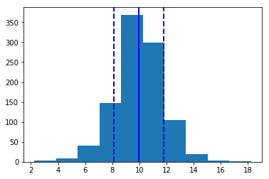

```python
loc, scale = 10, 1
logistic = np.random.logistic(loc, scale, 1000)

plot_hist(logistic)
```

```
Mean:  -0.08991587523734809
Std:  0.5339317290904458
```

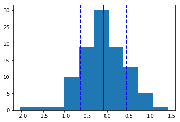

```python
mu, kappa = 0.0, 4.0 # mean and dispersion
vonmises = np.random.vonmises(mu, kappa, 100)
plot_hist(vonmises)
```

### Additionally:

```
Mean:  15.051424552456295
Std:  1.1675278150775956
```

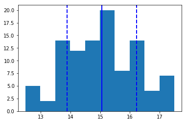

```python
normal1 = np.random.normal(5, 0.5, 100)
normal2 = np.random.normal(10, 1, 100)
added = normal1 + normal2
plot_hist(added)
```

- The mean is almost 15 (10 + 5), so the sum of both means of normal1 and normal2
- The standard deviation is not the sum of both origin standard deviation, but always higher than 1. So the standard deviation is not linear additive to each other
- nothing more special, just a normal distribution